# Demonstration of RelULSIF

# Introduction

This vignette assumes basic familiarity with time series data. It will start with a high-level overview of the RelULSIF algorithm followed by an application of this package to analyzing synthetic data.

## What is change point detection?

Change point detection is the task of determining which points in time the statistical properties (e.g. mean, standard deviation) of a time series or stochastic processes changes. Put another way, we look for time points at which the probability distribution of the series changes. The problem refers to both the question of whether or not a change has occurred and if so, at which time point it did occur. In more mathematical terms, suppose we have an ordered sequence of data $y_{N} = (y_1, \ldots, y_N)$. We say a change point has occurred if there exists a time point $t^* \in \{1, 2, \ldots, N - 1\}$ such that the statistical properties of $(y_1, \ldots, y_{t^*})$ and $(y_{t^*+1}, \ldots, y_N)$ are different in some way. RelULSIF solves this problem by computing the *ratio* of the probability distributions on either side of a time point.

# RelULSIF

Let’s begin by inventing a time series with some “obvious” change points (in mean) and some not so obvious change point (in mean and standard deviation).

```r
set.seed(2883)
series <- c(
    rnorm(50, mean = 0, sd = 0.3),
    rnorm(25, mean = 8, sd = 1),
    rnorm(75, mean = 3, sd = 0.6),
    rnorm(25, mean = 1, sd = 0.8),
    rnorm(100, mean = -5, sd = 1.5),
    rnorm(100, mean = -5, sd = 0.2),
    rnorm(50, mean = -2.5, sd = 0.4),
    rnorm(50, mean = 2, sd = 1.2)
)
```

And now visualize the series:

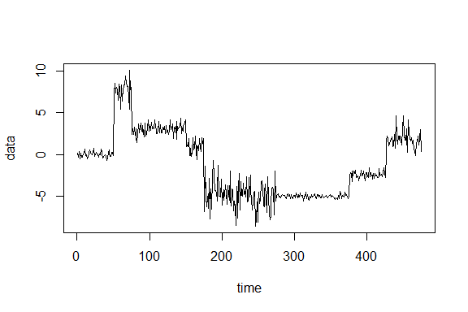

```r
plot(1:length(series), series, type = 'l', xlab = 'time', ylab = 'data')
```

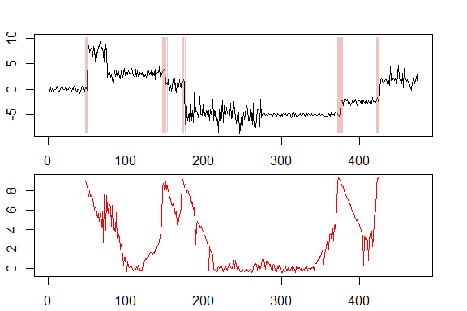

```r
# run the algorithm across the time series and plot the results
detect <- ts_detect(series, make_plot = TRUE)
```

Not too bad, but clearly not all change points are detected. Adjusting the algorithm’s hyperparameters may help us out.

## Adjusting the threshold

The simplest way to detect more change points that may be missing is simply to increase the sensitivity of detection, that is, decrease the parameter `thresh`. By default it’s set to 0.9 which means that for a time point to be classified as a change point, it’s corresponding rPE score must exceed the 90th percentile of rPE scores across the time series. Decreasing this parameter obviously increases the number of time point classified as change points.

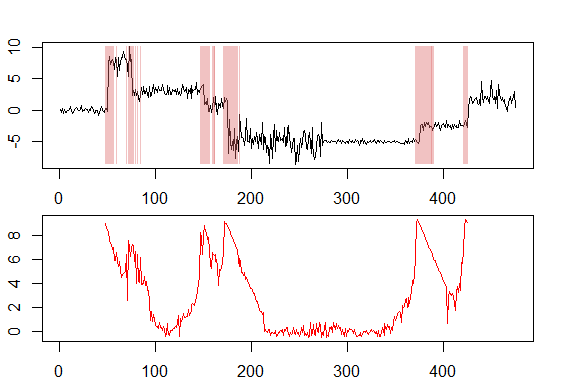

```r
detect_lower_thresh <- ts_detect(series, thresh = 0.65, make_plot = TRUE)
```

Lowering the threshold seems to have picked up a few more change points, but in practice when we don’t know how many true change points there are, the threshold parameter really only represents how likely we think a change point is to be or how sensitive we’d like the detection to be.

## Adjusting the window size

RelULSIF “looks” back and forward in the view of multiple *subsequences* of the data rather than just simply the previous and future $W$ time points. By increasing the window size $W$, we tell RelULSIF to gather more subsequences of the same length in the past and future to estimate the probability ratio. Making the window size too short may limit how much information is available while making it too long may mean that more subtle change points are overlooked.

The default window size is `5`, so let’s see first what happens when we make it a tad longer, say `20`.

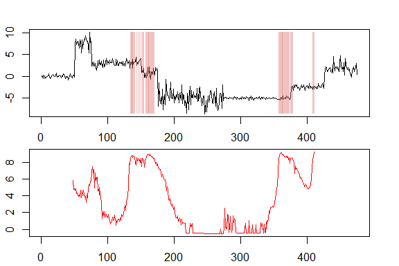

```r
detect_longer_window <- ts_detect(series, window_size = 20, make_plot = TRUE)
```

So that seems to have made it worse. The detected change points are shifted from before and the results seem more “sloopy”.

This should make sense, the lengths of several of the subsequences drawm from different parameter pairs aren’t too long so increasing the window size will “mix” some of them together (e.g. it would make the third and fourth subsequence look like they’re from the same distribution since their means are rather close).

However, there is one positive here: there are more peaks in the rPE around the area where the mean is held at -5 but the standard deviation changes from 1.5 to 0.2.

Now let’s try decreasing the window size to `3`.

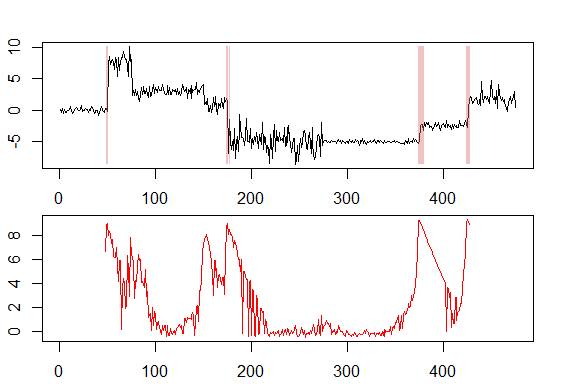

```r
detect_shorter_window <- ts_detect(series, window_size = 3, make_plot = TRUE)
```

Again it seems we are getting some peaks at that standard deviation change, but this time the results are a little neater and more accurate. We’re still missing some of the true change points, but we could just reduce the threshold to pick those up.

## Adjusting alpha

In some cases, the ratio of the probability densities $p(Y) / p'(Y)$ may be unbounded which is a problem since the standard ULSIF relies on the “sup”-norm. RelULSIF was introduced precisely to address this issue. The parameter `alpha` “smooths” the density ratio. When `alpha = 0`, we recover standard ULSIF. As `alpha` tends to 1, the density ratio gets “smoother”.

The default setting is `alpha = 0.05`. Let’s first set it to `0` to compare the results to standard ULSIF.

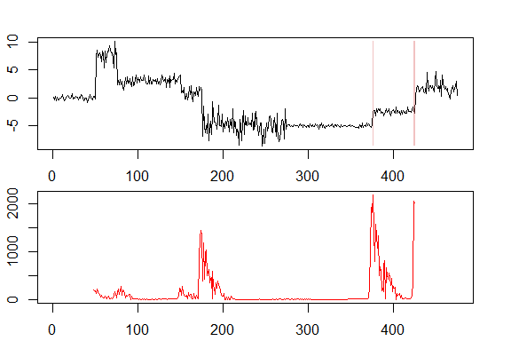

```r
detect_alpha_0 <- ts_detect(series, alpha = 0, make_plot = TRUE)
```

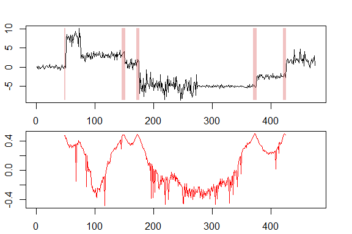

```r
detect_alpha_0.5 <- ts_detect(series, alpha = 0.5, make_plot = TRUE)
```

Pretty nasty, right?

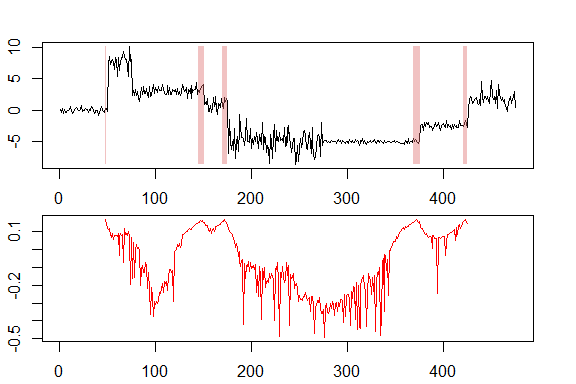

```r
detect_alpha_0.75 <- ts_detect(series, alpha = 0.75, make_plot = TRUE)
```

Still just as bad.

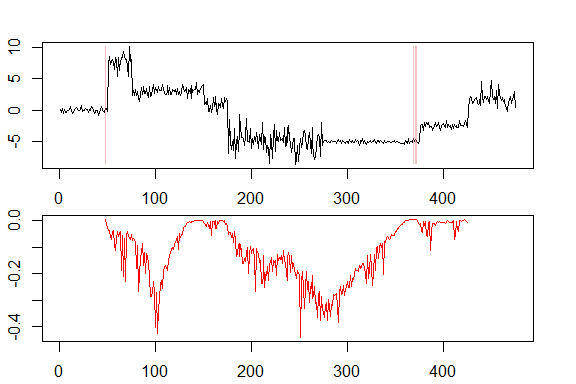

```r
detect_alpha_1 <- ts_detect(series, alpha = 0.99, make_plot = TRUE)
```

Alright, so increasing the alpha parameter seems to have made things worse in the sense that we get back less and less useful information on the probability density ratios. Keep in mind that the original implementation stuck with `0.01` as the default setting.

## Adjusting step

The last hyperparameter we’ll look at is `step` which determines where in the series of subsequences of the time series we begin our search. The default is 10% the length of the time series. Pulling the step back has the advantage of detecting earlier (and later, since it “widens” the search in both directions) time points, but the disadvantage of higher computation time in cases where that may be an issue.

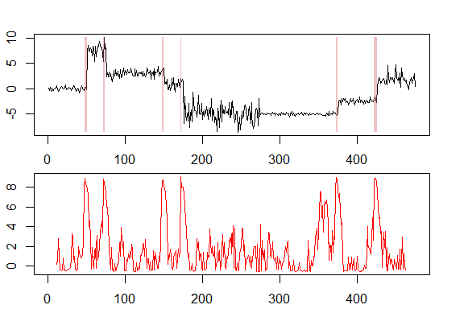

```r
detect_step_10 <- ts_detect(series, step = 10, make_plot = TRUE)
```

Now we’re really getting somewhere. Not only do we get much more distinct peaks at the true change points, we get more of a signal at that standard deviation change.

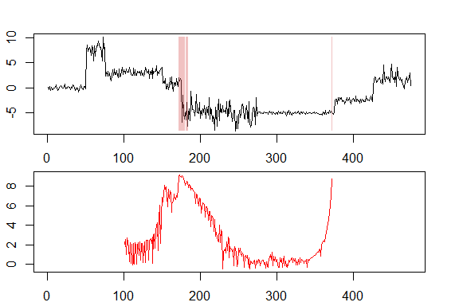

```r
detect_step_100 <- ts_detect(series, step = 100, make_plot = TRUE)
```

## Putting it all together

It seems that the adjustments that helped us the most were the ones to `window_size` and `step`. Let’s try a shorter window size and earlier step.

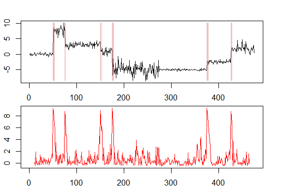

```r
detect_final <- ts_detect(series, window_size = 2, step = 10,
                          thresh = 0.6, make_plot = TRUE)
```

So not only have we picked up more of the true change points, but the detection bands are narrower making the results more accurate. We’d have “perfect” results were it not for that pesky standard deviation change, but in practice, the analyst would be wise not to rely just on the detection, but also the scores themselves to identify peaks. Comparing these peaks with the time series itself will prove just as informative.